# 2<sup>k</sup> Factorial Design

We can easily construct any factorial using the `expand.grid` function from R:

```r
expand.grid('A'=c(-1,1), 'B'=c(-1, 1), 'C'=c(-1, 1))
#    A  B  C
# 1 -1 -1 -1
# 2  1 -1 -1
# 3 -1  1 -1
# 4  1  1 -1
# 5 -1 -1  1
# 6  1 -1  1
# 7 -1  1  1
# 8  1  1  1
```

For an arbitrary $k$ we can use `lapply` to return the correct number of `c(-1,1)` values, and then use `do.call` to use those as an argument for `expand.grid`:

```r
fac2 <- function(k){
    as.data.frame(do.call(
        expand.grid,
        lapply(
            1:k,
            function(.){
                c(-1,1)
            }
        )
    ))
}

fac2(4)
#    Var1 Var2 Var3 Var4
# 1    -1   -1   -1   -1
# 2     1   -1   -1   -1
# 3    -1    1   -1   -1
# 4     1    1   -1   -1
# 5    -1   -1    1   -1
# 6     1   -1    1   -1
# 7    -1    1    1   -1
# 8     1    1    1   -1
# 9    -1   -1   -1    1
# 10    1   -1   -1    1
# 11   -1    1   -1    1
# 12    1    1   -1    1
# 13   -1   -1    1    1
# 14    1   -1    1    1
# 15   -1    1    1    1
# 16    1    1    1    1
```

# Section 6.2

Section 6.2 describes an experiment where the experimenter seeks to optimize yield by varying reactant concentration (`A`) and catalyst amount (`B`). I transcribed the data given in Figure 6.1.

```r
model <- aov(Yield ~ A*B, data=Figure6.1)
summary(model)
#             Df Sum Sq Mean Sq F value   Pr(>F)
# A            1 208.33  208.33  53.191 8.44e-05 ***
# B            1  75.00   75.00  19.149  0.00236 **
# A:B          1   8.33    8.33   2.128  0.18278
# Residuals    8  31.33    3.92
# ---
# Signif. codes:  0 '***' 0.001 '**' 0.01 '*' 0.05 '.' 0.1 ' ' 1
```

Table 6.2 gives the signs for calculating the effects. Here we replicate 3 times as in Figure 6.1. The `model.matrix` function shows us what is actually going into the linear model.

```r
model.matrix(~A*B, data=Figure6.1)
#    (Intercept)  A  B A:B
# 1            1 -1 -1   1
# 2            1  1 -1  -1
# 3            1 -1  1  -1
# 4            1  1  1   1
# 5            1 -1 -1   1
# 6            1  1 -1  -1
# 7            1 -1  1  -1
# 8            1  1  1   1
# 9            1 -1 -1   1
# 10           1  1 -1  -1
# 11           1 -1  1  -1
# 12           1  1  1   1
# attr(,"assign")
# [1] 0 1 2 3
```

Diagnostic plots for the model are given below.

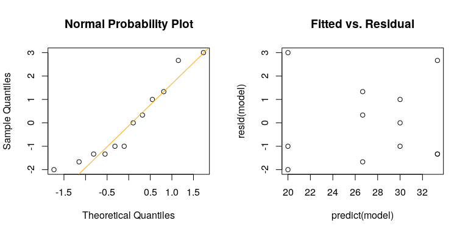

```r
model <- lm(Yield ~ A*B, data=Figure6.1)

op <- par(mfrow=c(1,2))
qqnorm(resid(model), main='Normal Probability Plot')
qqline(resid(model), col='orange')
plot(x=predict(model), y=resid(model), main='Fitted vs. Residual')
```

```r
par(op)
```

Figure 6.3 in the text contains a contour plot of the response surface. First, let’s model this as linear regression. Note that the text uses a *first order* model so it only contains main effects.

```r
model <- lm(Yield ~ A + B, data=Figure6.1)
summary(model)
#
# Call:
# lm(formula = Yield ~ A + B, data = Figure6.1)
#
# Residuals:
#     Min      1Q  Median      3Q     Max
# -2.8333 -1.9167  0.3333  1.8333  2.1667
#
# Coefficients:
#             Estimate Std. Error t value Pr(>|t|)
# (Intercept)   27.500      0.606  45.377 6.13e-12 ***
# A              4.167      0.606   6.875 7.27e-05 ***
# B             -2.500      0.606  -4.125  0.00258 **
# ---
# Signif. codes:  0 '***' 0.001 '**' 0.01 '*' 0.05 '.' 0.1 ' ' 1
#
# Residual standard error: 2.099 on 9 degrees of freedom
# Multiple R-squared:  0.8772,  Adjusted R-squared:  0.8499
# F-statistic: 32.14 on 2 and 9 DF,  p-value: 7.971e-05
```

Next, we plot the design points and show the contour plot.

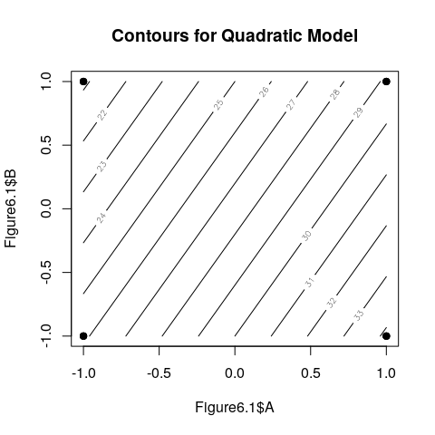

```r
plot(x=Figure6.1$A, y=Figure6.1$B, main='Contours for Quadratic Model', pch=19)
x <- seq(from=-1, to=1, length.out=100)
y <- seq(from=-1, to=1, length.out=100)
df <- expand.grid('A'=x, 'B'=y)
z <- matrix(predict(model, df), nrow=length(x))
contour(x=x, y=y, z=z, add=TRUE)
```

# Example 6.1 - Plasma Etching

A $2^3$ factorial design was executed to observe the effect of the gap between electrodes, gas flow, and RF-power on a plasma etching tool’s etch rate. The data is in Table 6.4. Compare the ANOVA table of Table 6.6 to the following.

```r
model <- aov(EtchRate ~ Gap * Flow * Power, data=Table6.4)
summary(model)
#                Df Sum Sq Mean Sq F value   Pr(>F)
# Gap             1  41311   41311  18.339 0.002679 **
# Flow            1    218     218   0.097 0.763911
# Power           1 374850  374850 166.411 1.23e-06 ***
# Gap:Flow        1   2475    2475   1.099 0.325168
# Gap:Power       1  94403   94403  41.909 0.000193 ***
# Flow:Power      1     18      18   0.008 0.930849
# Gap:Flow:Power  1    127     127   0.056 0.818586
# Residuals       8  18020    2253
# ---
# Signif. codes:  0 '***' 0.001 '**' 0.01 '*' 0.05 '.' 0.1 ' ' 1
```

The example also gives effect estimates. We can find the coefficients using the `coef` function. Recall that the effect size is twice the parameter estimate, so the effects are:

```r
2*coef(model)[-1]
#            Gap           Flow          Power       Gap:Flow      Gap:Power
#       -101.625          7.375        306.125        -24.875       -153.625
#     Flow:Power Gap:Flow:Power
#         -2.125          5.625
```

# Example 6.2 - Filtration Rate

In Example 6.2 the filtration rate of a chemical process is studied through a $2^4$ factorial design varying temperature, pressure, concentration of formaldehyde, and stirring rate. Since this is a saturated design we don’t have an estimate of error and can’t use the regular `aov` procedure. Doing so results simply in the partition of the sums of squares:

```r
model <- aov(Filtration ~ Temperature * Pressure * Formaldehyde * StirringRate, data=Table6.10)
summary(model)
#                                                Df Sum Sq Mean Sq
# Temperature                                     1 1870.6  1870.6
# Pressure                                        1   39.1    39.1
# Formaldehyde                                    1  390.1   390.1
# StirringRate                                    1  855.6   855.6
# Temperature:Pressure                            1    0.1     0.1
# Temperature:Formaldehyde                        1 1314.1  1314.1
# Pressure:Formaldehyde                           1   22.6    22.6
# Temperature:StirringRate                        1 1105.6  1105.6
# Pressure:StirringRate                           1    0.6     0.6
# Formaldehyde:StirringRate                       1    5.1     5.1
# Temperature:Pressure:Formaldehyde               1   14.1    14.1
# Temperature:Pressure:StirringRate               1   68.1    68.1
# Temperature:Formaldehyde:StirringRate           1   10.6    10.6
# Pressure:Formaldehyde:StirringRate              1   27.6    27.6
# Temperature:Pressure:Formaldehyde:StirringRate  1    7.6     7.6
```

Instead we can create a normal probability plot based on the effects:

```r
df <- Table6.10
colnames(df) <- c('A', 'B', 'C', 'D', 'Filtration', 'Block')
X <- model.matrix(~ -1 + A*B*C*D, data=df)
effects <- apply(X, 2, function(w){ sum((w*df$Filtration) / (0.5 * dim(df)[1])) })
names(effects) <- colnames(X)
effects
#       A       B       C       D     A:B     A:C     B:C     A:D     B:D
#  21.625   3.125   9.875  14.625   0.125 -18.125   2.375  16.625  -0.375
#     C:D   A:B:C   A:B:D   A:C:D   B:C:D A:B:C:D
#  -1.125   1.875   4.125  -1.625  -2.625   1.375
```

Plotting these we get

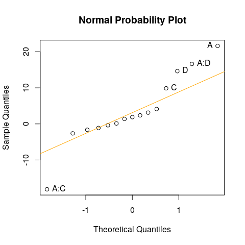

```r
locs <- qqnorm(effects, main='Normal Probability Plot')
qqline(effects, col='orange')
ix <- c(1,3,4,6,8)
text(x=locs$x[ix], y=locs$y[ix], labels=names(effects[ix]), pos=c(2, 4, 4, 4, 4))
```

If you compare this plot to the output in Figure 6.11 you’ll note that the line in the text better traces the central points than R’s `qqline`. This is because the `qqline` procedure is geared towards an overall normality assumption, whereas the line in Figure 6.11 is using a method that focuses on the interior points for establishing the variance of the distribution.

When the design is saturated, i.e. when there are no degrees of freedom for error, then the `halfnormal` function from package `DoE.base` (Groemping, Amarov, and Xu 2019) will construct a normal probability plot and label effects based on Lenth’s pseudo-p-value approach.

```r
library(DoE.base)

Fo <- Table6.10$Formaldehyde
Te <- Table6.10$Temperature
St <- Table6.10$StirringRate
Pr <- Table6.10$Pressure
Fi <- Table6.10$Filtration
model <- aov(Fi ~ Te * Pr * Fo * St, data=Table6.10)
vals <- halfnormal(model, alpha=0.1)
```

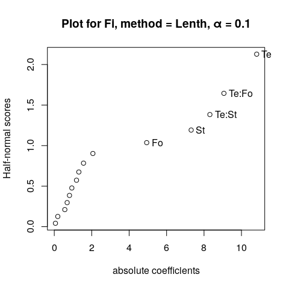

The returned object from `halfnormal` is a list with `signif` containing those factors that were significant at the $\alpha$ given.

```r
print(vals$signif)
# [1] "Fo"    "St"    "Te:St" "Te:Fo" "Te"
```

Next, we construct the contour plots of Figure 6.14.

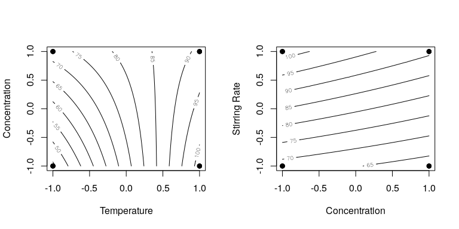

```r
op <- par(mfrow=c(1,2))
model <- lm(Filtration ~ A * C * D, data=df)

# Temperature (A) vs. Concentration (C)
plot(x=df$A, y=df$C, pch=19, xlab='Temperature', ylab='Concentration')
x <- seq(from=-1, to=1, length.out=100)
y <- seq(from=-1, to=1, length.out=100)
pre.z <- expand.grid('A'=x, 'C'=y)
pre.z[,'D'] <- rep(1, 100)
z <- matrix(predict(model, pre.z), nrow=length(x))
contour(x=x, y=y, z=z, add=TRUE)

# Concentration (C) vs. Stirring Rate (D)
plot(x=df$C, y=df$D, pch=19, xlab='Concentration', ylab='Stirring Rate')
x <- seq(from=-1, to=1, length.out=100)
y <- seq(from=-1, to=1, length.out=100)
pre.z <- expand.grid('C'=x, 'D'=y)
pre.z[,'A'] <- rep(1, 100)
z <- matrix(predict(model, pre.z), nrow=length(x))
contour(x=x, y=y, z=z, add=TRUE)
```

```r
par(op)
```

Compare Figure 6.18, where an outlier is removed, to the the following.

```r
model <- aov(Filtration ~ A * C * D, data=df)
vals <- halfnormal(model)
```

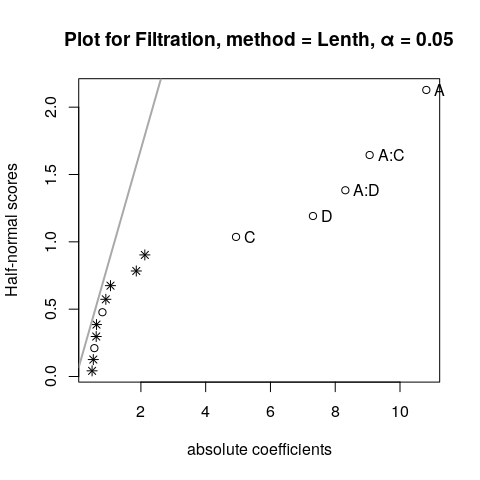

```r
print(vals$signif)
# [1] "C"   "D"   "A:D" "A:C" "A"
```

# Example 6.3 - Data Transformation in a Factorial Design

Example 6.3 describes an experiment where a $2^4$ factorial design was used to study the advance rate of a drill as a function of load, flow rate, rotation speed, and the type of drilling mud being used. The data is stored in `Example6.3`. First, we fit a regression model and then examine the half-normal probability plot.

```r
model <- lm(DrillRate ~ .*.*.*., data=Example6.3)
vals <- halfnormal(model)
```

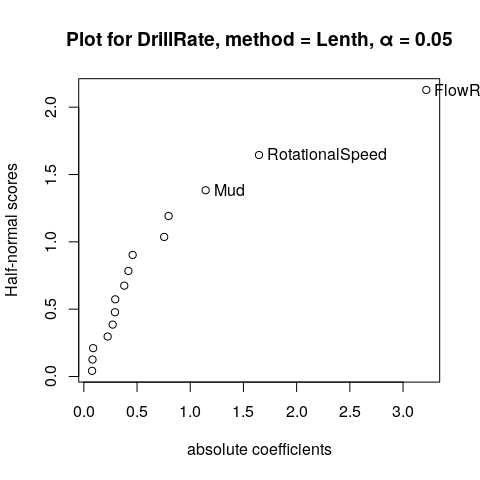

```r
print(vals$signif)
# [1] "Mud"             "RotationalSpeed" "FlowRate"
```

With `FlowRate`, `RotationalSpeed`, and `Mud` main effects all appearing significant, we examine the $2^3$ factorial replicated twice that’s left when we ignore `Load`.

```r
model2 <- aov(DrillRate ~ Mud + RotationalSpeed + FlowRate + FlowRate:Mud + FlowRate:RotationalSpeed, data=Example6.3)
summary(model2)
#                          Df Sum Sq Mean Sq F value   Pr(>F)
# Mud                       1  20.98   20.98  15.484  0.00280 **
# RotationalSpeed           1  43.36   43.36  32.009  0.00021 ***
# FlowRate                  1 165.77  165.77 122.363 6.26e-07 ***
# Mud:FlowRate              1  10.14   10.14   7.488  0.02096 *
# RotationalSpeed:FlowRate  1   9.12    9.12   6.732  0.02673 *
# Residuals                10  13.55    1.35
# ---
# Signif. codes:  0 '***' 0.001 '**' 0.01 '*' 0.05 '.' 0.1 ' ' 1
```

Next, let’s examine the predicted versus residual plot.

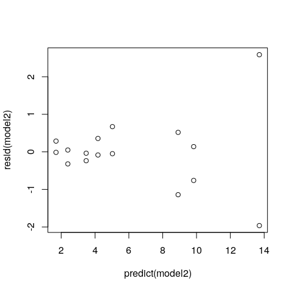

```r
plot(predict(model2), resid(model2))
```

The diagnostic plot shows severely unequal variance. As the text suggests, let’s look at the logarithm of `DrillRate`.

```r
df <- Example6.3
df[,'DrillRate'] <- log(df[,'DrillRate'])
model3 <- lm(DrillRate ~ .*.*.*., data=df)
vals <- halfnormal(model3)
```

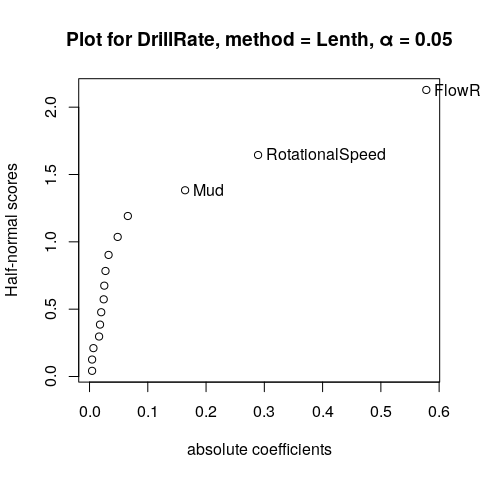

```r
print(vals$signif)
# [1] "Mud"             "RotationalSpeed" "FlowRate"
```

Again we find the three main effects to be active. We examine the ANOVA table of the reduced model and find that none of the interaction effects seem to be active.

```r
model4 <- lm(DrillRate ~ FlowRate * RotationalSpeed * Mud, data=df)
anova(model4)
# Analysis of Variance Table
#
# Response: DrillRate
#                              Df Sum Sq Mean Sq  F value    Pr(>F)
# FlowRate                      1 5.3452  5.3452 356.5307 6.399e-08 ***
# RotationalSpeed               1 1.3389  1.3389  89.3040 1.293e-05 ***
# Mud                           1 0.4305  0.4305  28.7173 0.0006786 ***
# FlowRate:RotationalSpeed      1 0.0095  0.0095   0.6320 0.4495577
# FlowRate:Mud                  1 0.0373  0.0373   2.4901 0.1532191
# RotationalSpeed:Mud           1 0.0007  0.0007   0.0479 0.8321670
# FlowRate:RotationalSpeed:Mud  1 0.0052  0.0052   0.3467 0.5722503
# Residuals                     8 0.1199  0.0150
# ---
# Signif. codes:  0 '***' 0.001 '**' 0.01 '*' 0.05 '.' 0.1 ' ' 1
```

We fit the main-effects-only model and check for normality of the residuals.

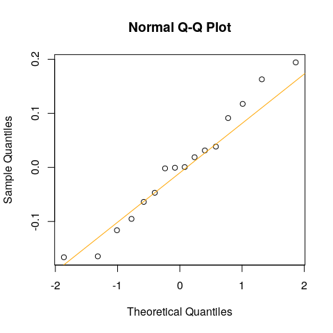

```r
model4 <- lm(DrillRate ~ FlowRate + RotationalSpeed + Mud, data=df)
qqnorm(resid(model4))
qqline(resid(model4), col='orange')
```

# Example 6.4 - Location and Dispersion Effects in an Unreplicated Factorial

The experiment in Example 6.4 seeks to minimize the number of defects by controlling the temperature, clamp time, resin flow, and closing time in a panel extruder. There’s two ways to improve the panel quality. First, we can decrease the mean number of defects. Second, we can reduce the variability of the number of defects. We begin with the mean defects.

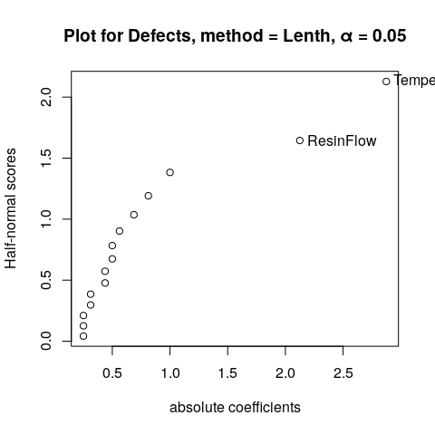

```
# [1] "ResinFlow"   "Temperature"
```

Only two of the main effects are active, so we examine the projection of the original $2^4$ design down to a $2^2$.

```r
model2 <- lm(Defects ~ Temperature * ResinFlow, data=Example6.4)
anova(model2)
# Analysis of Variance Table
#
# Response: Defects
#                       Df  Sum Sq Mean Sq F value   Pr(>F)
# Temperature            1 132.250 132.250  27.421 0.000209 ***
# ResinFlow              1  72.250  72.250  14.981 0.002226 **
# Temperature:ResinFlow  1   1.563   1.563   0.324 0.579727
# Residuals             12  57.875   4.823
# ---
# Signif. codes:  0 '***' 0.001 '**' 0.01 '*' 0.05 '.' 0.1 ' ' 1
```

The interaction effect is not significant so we proceed with the main-effects only model. We present the residual as a function of clamp-time below.

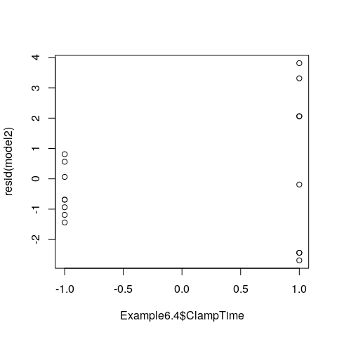

```r
model2 <- lm(Defects ~ Temperature + ResinFlow, data=Example6.4)
plot(Example6.4$ClampTime, resid(model2))
```

This suggests that the assumption of equal variance is incorrect, but also that minimizing `ClampTime` could reduce variability. Let us examine this idea further by calculating the dispersion effect in Example 6.4.

```r
ix <- Example6.4$ClampTime == 1
X <- model.matrix(Defects ~ -1 + . * . * . * ., data=Example6.4)
Fi.star <- apply(
    X,
    2,
    function(w){
        log(
            sd(resid(model2)[w == 1])^2
            /
            sd(resid(model2)[w != 1])^2
        )
    }
)
vals <- halfnormal(Fi.star)
```

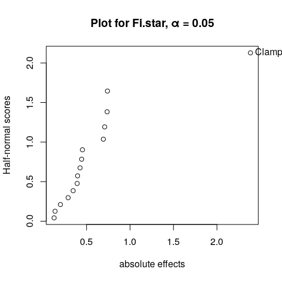

Indeed, `ClampTime` has a strong effect on variability.

# Example 6.5 - Duplicate Measurements on the Response

In this experiment engineers stacked four wafers in a vertical oxidation furnace and examined the effect of temperature, time, pressure, and gas flow on the oxide thinness of the wafer. Note that since the wafers were all exposed at the same time they don’t count as separate runs, and are instead examples of repeated measurements. We begin by examining the sample variance of the wafers in a run.

```r
df <- aggregate(OxideThickness ~ ., data=Table6.18, FUN=mean)
df[,'SampleVariance'] <- aggregate(OxideThickness ~ ., data=Table6.18, FUN=var)[,'OxideThickness']
```

| Temperature | Time | Pressure | GasFlow | OxideThickness | SampleVariance |
| --- | --- | --- | --- | --- | --- |
| -1 | -1 | -1 | -1 | 378 | 2.0000000 |
| 1 | -1 | -1 | -1 | 416 | 0.6666667 |
| -1 | 1 | -1 | -1 | 381 | 3.3333333 |
| 1 | 1 | -1 | -1 | 448 | 3.3333333 |
| -1 | -1 | 1 | -1 | 372 | 6.6666667 |
| 1 | -1 | 1 | -1 | 390 | 2.0000000 |
| -1 | 1 | 1 | -1 | 385 | 0.6666667 |
| 1 | 1 | 1 | -1 | 430 | 8.6666667 |
| -1 | -1 | -1 | 1 | 380 | 12.0000000 |
| 1 | -1 | -1 | 1 | 415 | 14.6666667 |
| -1 | 1 | -1 | 1 | 371 | 0.6666667 |
| 1 | 1 | -1 | 1 | 446 | 6.0000000 |
| -1 | -1 | 1 | 1 | 378 | 1.3333333 |
| 1 | -1 | 1 | 1 | 392 | 34.0000000 |
| -1 | 1 | 1 | 1 | 376 | 0.6666667 |
| 1 | 1 | 1 | 1 | 429 | 1.3333333 |

Next, we partition the effects and sums of squares for the mean oxide thickness over the four wafers.

```r
model <- lm(OxideThickness ~ Temperature * Time * Pressure * GasFlow, data=df)
model.ss <- anova(model)[['Sum Sq']]
# Warning in anova.lm(model): ANOVA F-tests on an essentially perfect fit are
# unreliable
effect.estimates <- data.frame(
    'EffectEstimate'=2 * coef(model)[-1],
    'SumOfSquares'=model.ss[-1],
    'Contribution'=sprintf('%0.2f%%', 100*model.ss[-1]/sum(model.ss[-1]))
)
```

|  | EffectEstimate | SumOfSquares | Contribution |
| --- | --- | --- | --- |
| Temperature | 43.125 | 1314.0625 | 37.42% |
| Time | 18.125 | 430.5625 | 12.26% |
| Pressure | -10.375 | 10.5625 | 0.30% |
| GasFlow | -1.625 | 1139.0625 | 32.44% |
| Temperature:Time | 16.875 | 451.5625 | 12.86% |
| Temperature:Pressure | -10.625 | 60.0625 | 1.71% |
| Time:Pressure | 3.875 | 5.0625 | 0.14% |
| Temperature:GasFlow | 1.125 | 60.0625 | 1.71% |
| Time:GasFlow | -3.875 | 5.0625 | 0.14% |
| Pressure:GasFlow | 1.125 | 0.5625 | 0.02% |
| Temperature:Time:Pressure | -0.375 | 33.0625 | 0.94% |
| Temperature:Time:GasFlow | 2.875 | 0.0625 | 0.00% |
| Temperature:Pressure:GasFlow | -0.125 | 1.5625 | 0.04% |
| Time:Pressure:GasFlow | -0.625 | 0.0625 | 0.00% |
| Temperature:Time:Pressure:GasFlow | 0.125 | 0.0000 | 0.00% |

Examining the half-normal probability plot we find `Temperature`, `Time`, `Pressure`, and the interactions of `Temperature` with `Time` and `Pressure` to be significant.

```r
vals <- halfnormal(model)
```

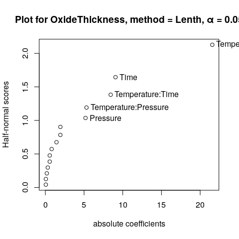

```r
print(vals$signif)
# [1] "Pressure"             "Temperature:Pressure" "Temperature:Time"
# [4] "Time"                 "Temperature"
```

Fitting this reduced model shows good significance.

```r
model2 <- lm(OxideThickness ~ Temperature + Time + Temperature:Time + Pressure + Temperature:Pressure, data=df)
anova(model2)
# Analysis of Variance Table
#
# Response: OxideThickness
#                      Df Sum Sq Mean Sq F value    Pr(>F)
# Temperature           1 7439.1  7439.1 422.374 1.644e-09 ***
# Time                  1 1314.1  1314.1  74.610 5.978e-06 ***
# Pressure              1  430.6   430.6  24.446 0.0005834 ***
# Temperature:Time      1 1139.1  1139.1  64.674 1.125e-05 ***
# Temperature:Pressure  1  451.6   451.6  25.639 0.0004895 ***
# Residuals            10  176.1    17.6
# ---
# Signif. codes:  0 '***' 0.001 '**' 0.01 '*' 0.05 '.' 0.1 ' ' 1
```

The parameter estimates are given next.

```r
summary(model2)
#
# Call:
# lm.default(formula = OxideThickness ~ Temperature + Time + Temperature:Time +
#     Pressure + Temperature:Pressure, data = df)
#
# Residuals:
#    Min     1Q Median     3Q    Max
# -7.125 -2.469  1.000  2.250  6.625
#
# Coefficients:
#                      Estimate Std. Error t value Pr(>|t|)
# (Intercept)           399.188      1.049 380.475  < 2e-16 ***
# Temperature            21.562      1.049  20.552 1.64e-09 ***
# Time                    9.063      1.049   8.638 5.98e-06 ***
# Pressure               -5.187      1.049  -4.944 0.000583 ***
# Temperature:Time        8.437      1.049   8.042 1.12e-05 ***
# Temperature:Pressure   -5.313      1.049  -5.063 0.000489 ***
# ---
# Signif. codes:  0 '***' 0.001 '**' 0.01 '*' 0.05 '.' 0.1 ' ' 1
#
# Residual standard error: 4.197 on 10 degrees of freedom
# Multiple R-squared:  0.9839,  Adjusted R-squared:  0.9759
# F-statistic: 122.3 on 5 and 10 DF,  p-value: 1.237e-08
```

Next, we plot the response surface.

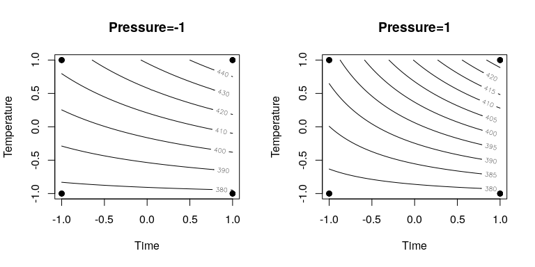

```r
op <- par(mfrow=c(1,2))

plot(x=df$Time, y=df$Temperature, pch=19, xlab='Time', ylab='Temperature', main='Pressure=-1')
x <- seq(from=-1, to=1, length.out=100)
y <- seq(from=-1, to=1, length.out=100)
pre.z <- expand.grid('Time'=x, 'Temperature'=y)
pre.z[,'Pressure'] <- rep(-1, 100)
z <- matrix(predict(model2, pre.z), nrow=length(x))
contour(x=x, y=y, z=z, add=TRUE)

plot(x=df$Time, y=df$Temperature, pch=19, xlab='Time', ylab='Temperature', main='Pressure=1')
x <- seq(from=-1, to=1, length.out=100)
y <- seq(from=-1, to=1, length.out=100)
pre.z <- expand.grid('Time'=x, 'Temperature'=y)
pre.z[,'Pressure'] <- rep(1, 100)
z <- matrix(predict(model2, pre.z), nrow=length(x))
contour(x=x, y=y, z=z, add=TRUE)
```

```r
par(op)
```

Consider now the log transform of the sample variance at each set of four wafers.

```r
Y <- log(df[,'SampleVariance'])
model <- lm(Y ~ Temperature * Time * Pressure * GasFlow, data=df)
vals <- halfnormal(model)
```

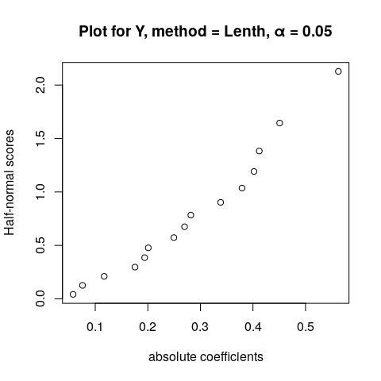

```r
print(vals$signif)
# character(0)
```

The text notes there are no strong effects but that factor `A` and `B:D` are largest, so we fit that model.

```r
model <- lm(Y ~ Temperature + Time + GasFlow + Time:GasFlow, data=df)
summary(model)
#
# Call:
# lm.default(formula = Y ~ Temperature + Time + GasFlow + Time:GasFlow,
#     data = df)
#
# Residuals:
#     Min      1Q  Median      3Q     Max
# -1.5464 -0.4391 -0.1105  0.6648  1.5896
#
# Coefficients:
#              Estimate Std. Error t value Pr(>|t|)
# (Intercept)    1.0808     0.2641   4.092  0.00178 **
# Temperature    0.4120     0.2641   1.560  0.14708
# Time          -0.4020     0.2641  -1.522  0.15623
# GasFlow        0.2008     0.2641   0.760  0.46305
# Time:GasFlow  -0.5625     0.2641  -2.130  0.05661 .
# ---
# Signif. codes:  0 '***' 0.001 '**' 0.01 '*' 0.05 '.' 0.1 ' ' 1
#
# Residual standard error: 1.057 on 11 degrees of freedom
# Multiple R-squared:  0.4728,  Adjusted R-squared:  0.281
# F-statistic: 2.466 on 4 and 11 DF,  p-value: 0.1065
```

Next, we present the contour plot of this surface.

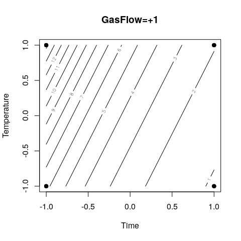

```r
plot(x=df$Time, y=df$Temperature, pch=19, xlab='Time', ylab='Temperature', main='GasFlow=+1')
x <- seq(from=-1, to=1, length.out=100)
y <- seq(from=-1, to=1, length.out=100)
pre.z <- expand.grid('Time'=x, 'Temperature'=y)
pre.z[,'GasFlow'] <- rep(1, 100)
z <- matrix(predict(model, pre.z), nrow=length(x))
contour(x=x, y=y, z=exp(z), add=TRUE)
```

# Example 6.6 - Credit Card Marketing

An experiment to increase direct mail sales was undertaken by a financial services company. They examined varying the annual fee, the account-opening fee, the initial interest rate, and the long term interest rate in a $2^4$ design. The half-normal plot of effects is presented next.

```r
model <- lm(ResponseRate ~ .*.*.*., data=Table6.22)
vals <- halfnormal(model, alpha=0.1)
```

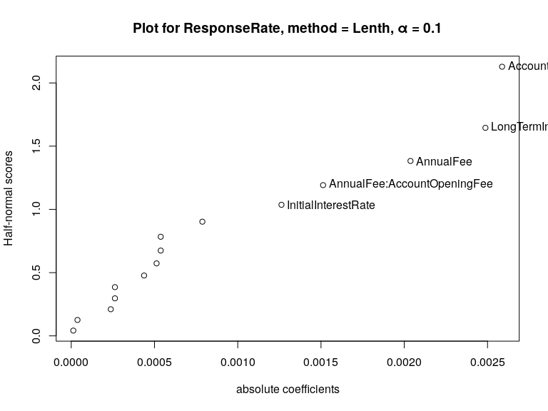

```r
print(vals$signif)
# [1] "InitialInterestRate"         "AnnualFee:AccountOpeningFee"
# [3] "AnnualFee"                   "LongTermInterestRate"
# [5] "AccountOpeningFee"
```

Putting these active effects into a regression model we find the coefficient estimates:

```r
model <- lm(
    ResponseRate ~ AnnualFee + AccountOpeningFee + InitialInterestRate + LongTermInterestRate + AnnualFee:AccountOpeningFee,
    data=Table6.22
)
summary(model)
#
# Call:
# lm.default(formula = ResponseRate ~ AnnualFee + AccountOpeningFee +
#     InitialInterestRate + LongTermInterestRate + AnnualFee:AccountOpeningFee,
#     data = Table6.22)
#
# Residuals:
#        Min         1Q     Median         3Q        Max
# -0.0036250 -0.0006250  0.0001125  0.0007063  0.0026000
#
# Coefficients:
#                               Estimate Std. Error t value Pr(>|t|)
# (Intercept)                  0.0236375  0.0004299  54.989 9.59e-14 ***
# AnnualFee                    0.0020375  0.0004299   4.740 0.000792 ***
# AccountOpeningFee           -0.0025875  0.0004299  -6.019 0.000129 ***
# InitialInterestRate          0.0012625  0.0004299   2.937 0.014862 *
# LongTermInterestRate        -0.0024875  0.0004299  -5.787 0.000176 ***
# AnnualFee:AccountOpeningFee -0.0015125  0.0004299  -3.519 0.005552 **
# ---
# Signif. codes:  0 '***' 0.001 '**' 0.01 '*' 0.05 '.' 0.1 ' ' 1
#
# Residual standard error: 0.001719 on 10 degrees of freedom
# Multiple R-squared:  0.9188,  Adjusted R-squared:  0.8782
# F-statistic: 22.64 on 5 and 10 DF,  p-value: 3.722e-05
```

From this we could calculate the best combination.

# Example 6.7

Recall the experiment in Example 6.2. In this example we need to add some center runs:

```r
str(Table6.10)
# 'data.frame': 16 obs. of  6 variables:
#  $ Temperature : num  -1 1 -1 1 -1 1 -1 1 -1 1 ...
#  $ Pressure    : num  -1 -1 1 1 -1 -1 1 1 -1 -1 ...
#  $ Formaldehyde: num  -1 -1 -1 -1 1 1 1 1 -1 -1 ...
#  $ StirringRate: num  -1 -1 -1 -1 -1 -1 -1 -1 1 1 ...
#  $ Filtration  : num  45 71 48 65 68 60 80 65 43 100 ...
#  $ Block       : Factor w/ 2 levels "1","2": 1 2 2 1 2 1 1 2 2 1 ...
```

We add `NA` for the `Block` level , otherwise adding the center runs given in the example.

```r
Example6.7 <- rbind(
    Table6.10,
    c(0, 0, 0, 0, 73, NA),
    c(0, 0, 0, 0, 75, NA),
    c(0, 0, 0, 0, 66, NA),
    c(0, 0, 0, 0, 69, NA)
)
model1 <- lm(Filtration ~ Temperature*Pressure*Formaldehyde*StirringRate, data=Example6.7)
model2 <- lm(Filtration ~ Temperature*Pressure*Formaldehyde*StirringRate + I(Temperature^2) + I(Pressure^2) + I(Formaldehyde^2) + I(StirringRate^2), data=Example6.7)
anova(model1, model2)
# Analysis of Variance Table
#
# Model 1: Filtration ~ Temperature * Pressure * Formaldehyde * StirringRate
# Model 2: Filtration ~ Temperature * Pressure * Formaldehyde * StirringRate +
#     I(Temperature^2) + I(Pressure^2) + I(Formaldehyde^2) + I(StirringRate^2)
#   Res.Df    RSS Df Sum of Sq      F Pr(>F)
# 1      4 50.262
# 2      3 48.750  1    1.5125 0.0931 0.7802
```

Above, the partial $F$-test shows that a quadratic model doesn’t add much to the quality of our model.

Next we examine if quadratic effects help a reduced model.

```r
model1 <- lm(Filtration ~ Temperature + Formaldehyde + StirringRate + Temperature:Formaldehyde + Temperature:StirringRate, data=Example6.7)
model2 <- lm(Filtration ~ Temperature + Formaldehyde + StirringRate + Temperature:Formaldehyde + Temperature:StirringRate + I(Temperature^2) + I(Formaldehyde^2) + I(StirringRate^2), data=Example6.7)
anova(model1, model2)
# Analysis of Variance Table
#
# Model 1: Filtration ~ Temperature + Formaldehyde + StirringRate + Temperature:Formaldehyde +
#     Temperature:StirringRate
# Model 2: Filtration ~ Temperature + Formaldehyde + StirringRate + Temperature:Formaldehyde +
#     Temperature:StirringRate + I(Temperature^2) + I(Formaldehyde^2) +
#     I(StirringRate^2)
#   Res.Df    RSS Df Sum of Sq      F Pr(>F)
# 1     14 245.39
# 2     13 243.88  1    1.5125 0.0806 0.7809
```

# Section 6.9 - Why We Work with Coded Design Variables

Section 6.9 compares the regression model on the natural units to the coded units. We begin with the natural units.

```r
model <- lm(V ~ I * R, data=Table6.25)
summary(model)
#
# Call:
# lm.default(formula = V ~ I * R, data = Table6.25)
#
# Residuals:
#       1       2       3       4       5       6       7       8
# -0.1055  0.1055  0.0365 -0.0365 -0.1125  0.1125 -0.1365  0.1365
#
# Coefficients:
#             Estimate Std. Error t value Pr(>|t|)
# (Intercept)  -0.8055     0.8432  -0.955 0.393518
# I             0.1435     0.1654   0.868 0.434467
# R             0.4710     0.5333   0.883 0.427003
# I:R           0.9170     0.1046   8.768 0.000933 ***
# ---
# Signif. codes:  0 '***' 0.001 '**' 0.01 '*' 0.05 '.' 0.1 ' ' 1
#
# Residual standard error: 0.1479 on 4 degrees of freedom
# Multiple R-squared:  0.9988,  Adjusted R-squared:  0.9979
# F-statistic:  1086 on 3 and 4 DF,  p-value: 2.818e-06
```

In coded units this yields:

```r
model <- lm(V ~ x1 * x2, data=Table6.25)
summary(model)
#
# Call:
# lm.default(formula = V ~ x1 * x2, data = Table6.25)
#
# Residuals:
#       1       2       3       4       5       6       7       8
# -0.1055  0.1055  0.0365 -0.0365 -0.1125  0.1125 -0.1365  0.1365
#
# Coefficients:
#             Estimate Std. Error t value Pr(>|t|)
# (Intercept)  7.49600    0.05229 143.349 1.42e-08 ***
# x1           1.51900    0.05229  29.049 8.36e-06 ***
# x2           2.52800    0.05229  48.344 1.10e-06 ***
# x1:x2        0.45850    0.05229   8.768 0.000933 ***
# ---
# Signif. codes:  0 '***' 0.001 '**' 0.01 '*' 0.05 '.' 0.1 ' ' 1
#
# Residual standard error: 0.1479 on 4 degrees of freedom
# Multiple R-squared:  0.9988,  Adjusted R-squared:  0.9979
# F-statistic:  1086 on 3 and 4 DF,  p-value: 2.818e-06
```

The coded unit version produced a model where all of the terms were significant, whereas the natural units model only found the interaction significant. Note that both models have the same $R^2$ values and so are equally good fits. But note how the standard error on the coefficients changes between the two formulations of the model.

# References

Groemping, Ulrike, Boyko Amarov, and Hongquan Xu. 2019. *DoE.base: Full Factorials, Orthogonal Arrays and Base Utilities for Doe Packages*. https://cran.r-project.org/package=DoE.base.